# Temperature responses

Til Hämmig, Francesco Polazzo, Owen L. Petchey, Frank Pennekamp

24 July, 2025

# 1 Introduction

Central to the concept of response diversity is that species respond to a change in the environment, in our case a fluctuation in temperature. Our monoculture data clearly showed that species performances changed along the temperature gradient. Here we provide further evidence that this holds true in the community experiment. We relate species responses in monoculture to the regression coefficient of temperature against biomass, and find a positive relationship, meaning that positive responses were associated with an increase in biomass with temperature while negative responses were related to a decrease (Fig. 1 & 2).

## 1.1 Species responses to temperature

T0: Does temperature on sampling day explain biomass?

T1: Does temperature on the day before sampling day explain biomass?

T2: Does average temperature over the two days before sampling day explain biomass?

T3: Does average temperature over the three days before sampling day explain biomass?

## 1.2 Overall correlation

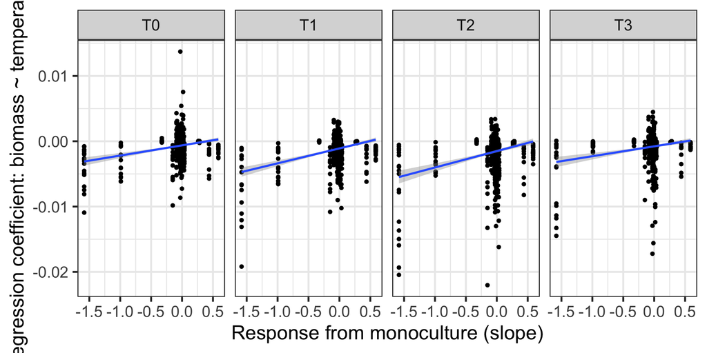

**Figure 1**: Relationship between species’ responses to temperature from monoculture and from the community experiment. The positive relationship is evidence that species were responding to the fluctuating temperature regime in the community experiment.

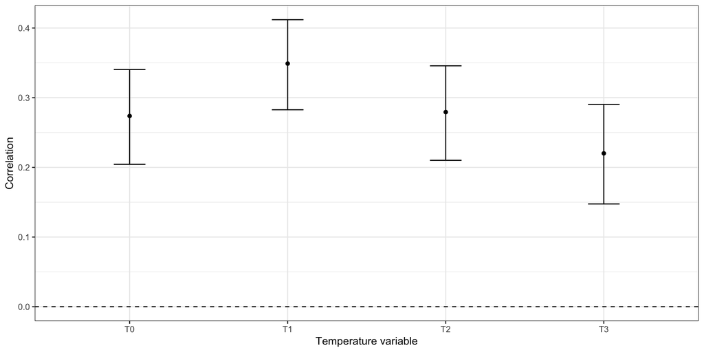

**Figure 2**: Correlation between regression coefficients (biomass~temperature) from the community experiment and from monoculture responses (slope). Positive correlations indicate that species in polyculture were responding according to the responses estimated from the monocultre experiment.

## 1.3 Species level

Depending on the magnitude of the different responses more time is required for a change in performance to result in a detectable change in biomass. We looked at species individually to understand how responsive they were to temperature fluctuations (Tab. 1 & Fig. 3). We found strong evidence for Colpidium (C), and weak / mixed evidence for all the other species. Colpidium had by far the strongest responses (largest slopes) (Fig. 4). Thus, it is expected that we would also find the clearest signal.

Correlation between Slope and Temperature Coefficients

| Species | Time lag | Correlation (r) | 95% Confidence Interval | p-value |
| --- | --- | --- | --- | --- |
| C | T0 | 0.39 | [0.241, 0.52] | 1.4e-06 |
| C | T1 | 0.437 | [0.294, 0.561] | 4.3e-08 |
| C | T2 | 0.289 | [0.131, 0.432] | 0.00045 |
| C | T3 | 0.202 | [0.037, 0.357] | 0.017 |
| D | T0 | -0.34 | [-0.476, -0.189] | 2.5e-05 |
| D | T1 | -0.187 | [-0.339, -0.026] | 0.023 |
| D | T2 | -0.04 | [-0.2, 0.123] | 0.63 |
| D | T3 | 0.232 | [0.065, 0.387] | 0.0069 |
| L | T0 | -0.276 | [-0.425, -0.111] | 0.0013 |
| L | T1 | -0.108 | [-0.273, 0.063] | 0.21 |
| L | T2 | -0.005 | [-0.174, 0.165] | 0.96 |
| L | T3 | 0.009 | [-0.166, 0.183] | 0.92 |
| P | T0 | 0.065 | [-0.111, 0.237] | 0.47 |
| P | T1 | 0.078 | [-0.098, 0.25] | 0.39 |
| P | T2 | 0.012 | [-0.163, 0.187] | 0.89 |
| P | T3 | 0.041 | [-0.135, 0.214] | 0.65 |
| S | T0 | -0.01 | [-0.165, 0.145] | 0.9 |
| S | T1 | 0.104 | [-0.052, 0.255] | 0.19 |
| S | T2 | 0.136 | [-0.019, 0.285] | 0.086 |
| S | T3 | 0.133 | [-0.025, 0.283] | 0.098 |

**Table 1**: Species level correlation between regression coefficients (biomass~temperature) from the community experiment and from monoculture responses (slope)

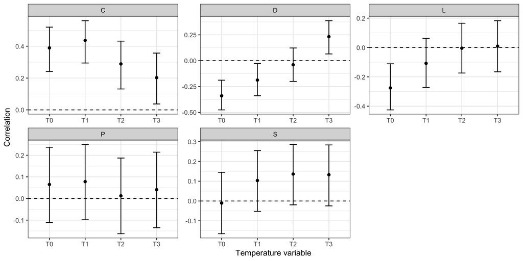

**Figure 3**: Species level correlation between regression coefficients (biomass~temperature) from the community experiment and from monoculture responses (slope).

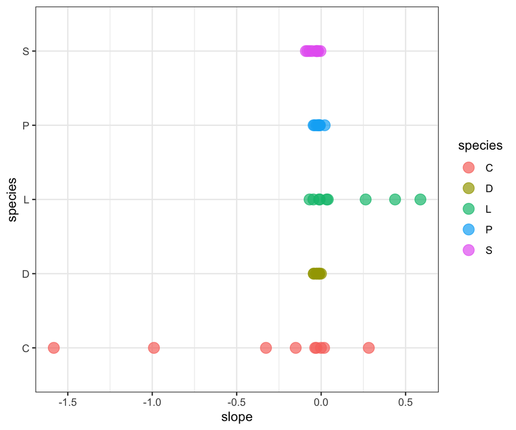

**Figure 4**: Distributions of species responses.

## 1.4 Window analysis

We looked at how the responsiveness to temperature changed over time using a moving window approach (Fig. 5). We found that responsiveness was highest in the beginning of the experiment.

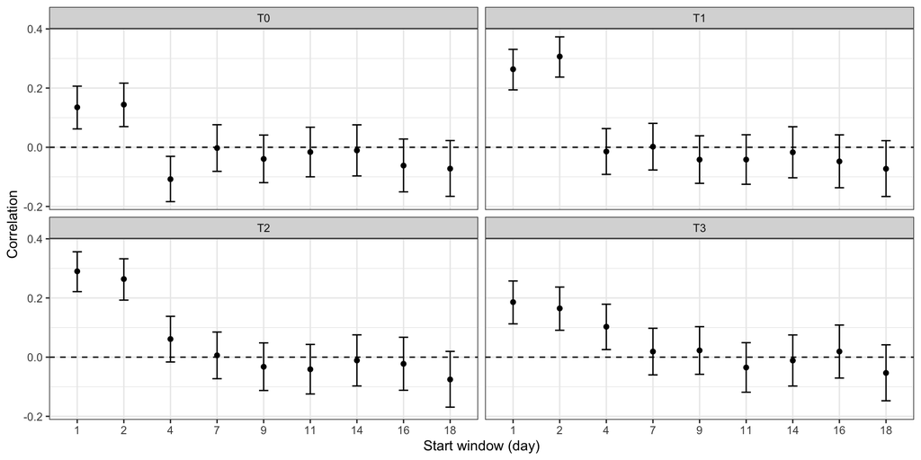

**Figure 5**: Window analysis for T0 - T3: Correlation between regression coefficients (biomass~temperature) from the community experiment and from monoculture responses (slope). Every window contains 6 sampling days with +1 sampling day displacement between windows.